# Istanbul Extras

Can Hakan Dagidir

2022

## Intro

Estimation and Comparison of **Prediction Intervals** using **QRLSTM** and **Historical Forecast Similarity** on Istanbul’s Traffic Data.

## Methods

We will use 2 different approaches.

1. **QRLSTM:**
   - Directly estimates wanted **quantiles** with an **LSTM network**.
   - Called QRLSTM because of the unique **loss function** that is **uneven** weighted
   - Using the specific quantiles for creating **Prediction Intervals**
2. **Forecast Similarity**
   - First, makes a **point estimate** of the traffic flow.
   - Then, uses these estimations as a **time–series** data
   - Creates **time-windows** of forecast-time-series data
   - Calculates the **similarity** between different time-windows using **different metrics**
   - Using **similar time windows** for creating **Prediction Intervals**

## Data

The data provided had many missing instances.

4 different methods for handling missing data (not to be included in this report)

1. Remove NA
2. Using ARIMA for predicting missing data
3. Mean of every same hour
4. Mean of every same hour of the same day (e.g. Monday 4:00)

### Data Prep

1. Remove outliers:
   - Get 0.999th and 0.001th quantile of the data and set the outliers to corresponding quantile values.

```r
# Set outliers to the corresponding quantile : 0.999 and 0.001
upquant = quantile(d1$flow,0.999) # this changes with data: d1>d2=d3=d4 but we use same for all
downquant = quantile(d1$flow,0.001) # downquant = 12 for all datasets. 10 and 11 will be set to 12.

d1 <- d1 %>% mutate(flow = ifelse(flow > upquant, upquant, ifelse(flow < downquant, downquant ,flow)))
d2 <- d2 %>% mutate(flow = ifelse(flow > upquant, upquant, ifelse(flow < downquant, downquant ,flow)))
d3 <- d3 %>% mutate(flow = ifelse(flow > upquant, upquant, ifelse(flow < downquant, downquant ,flow)))
d4 <- d4 %>% mutate(flow = ifelse(flow > upquant, upquant, ifelse(flow < downquant, downquant ,flow)))
```

2. Min/Max scaling the data.
   - For compatibility with previous Istanbul Project
   - Code skipped
3. A peek at our data:

```r
head(d1)
```

| index | flow |
| --- | --- |
| 0 | 0.2327139 |
| 1 | 0.2143417 |
| 2 | 0.1980109 |
| 3 | 0.1286050 |
| 4 | 0.1081915 |
| 5 | 0.1020675 |

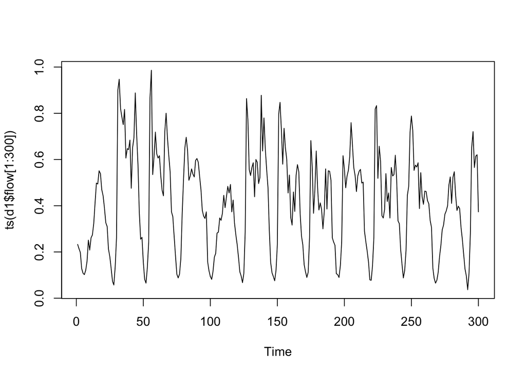

```r
plot(ts(d1$flow[1:300]))
```

4. Create a lagged data (for LSTM input):

   $$X_{t−169}, X_{t−168}, X_{t−167}, X_{t−25}, X_{t−24}, X_{t−23}, X_{t−2}
   \text{ and } X_{t−1}$$

```r
# custom function: createLagged (can be checked from github)
a1 = createLagged(data = d1,lags = c(-169:-167, -25:-23, -2:0), other.head = 1)
```

```r
head(a1)
```

| index | flow_lag169 | flow_lag168 | flow_lag167 | flow_lag25 | flow_lag24 | flow_lag23 | flow_lag2 | flow_lag1 | flow |
| --- | --- | --- | --- | --- | --- | --- | --- | --- | --- |
| 169 | 0.2327139 | 0.2143417 | 0.1980109 | 0.15514257 | 0.11023288 | 0.09390208 | 0.26945814 | 0.23067250 | 0.14493582 |
| 170 | 0.2143417 | 0.1980109 | 0.1286050 | 0.11023288 | 0.09390208 | 0.07552993 | 0.23067250 | 0.14493582 | 0.11431558 |
| 171 | 0.1980109 | 0.1286050 | 0.1081915 | 0.09390208 | 0.07552993 | 0.12043963 | 0.14493582 | 0.11431558 | 0.08981938 |
| 172 | 0.1286050 | 0.1081915 | 0.1020675 | 0.07552993 | 0.12043963 | 0.23271385 | 0.11431558 | 0.08981938 | 0.11227423 |
| 173 | 0.1081915 | 0.1020675 | 0.1204396 | 0.12043963 | 0.23271385 | 0.79612634 | 0.08981938 | 0.11227423 | 0.26129275 |
| 174 | 0.1020675 | 0.1204396 | 0.1592253 | 0.23271385 | 0.79612634 | 0.84716007 | 0.11227423 | 0.26129275 | 0.68181076 |

4. Matrix to 3D array transformation (that’s how LSTM wants)
   - Code skipped

## QRLSTM

We will be using {tensorflow} and {keras} R-packages.

```r
library(tensorflow)
library(keras)
```

1. Create a custom quantile loss function:
   - Note that: coding of the function is highly likely to be very bad. I am unfamiliar with tensorflow.

```r
# tau might be changed to 1-tau. [Not sure]
pinball_loss <- function(y_pred, y_true, tau) {
    y_pred = tf$convert_to_tensor(y_pred)
    y_true = tf$cast(y_true, y_pred$dtype)
    #
    tau = tf$expand_dims(tf$cast(tau, y_pred$dtype), as.integer(0))
    one = tf$cast(1, tau$dtype)
    #
    delta_y = y_true - y_pred
    pinball = tf$math$maximum(tau * delta_y, (tau - one) * delta_y)
    return(tf$reduce_mean(pinball, axis = as.integer(-1)))
}
```

2. LSTM NETWORK:
   - Here is the code for one of the datasets.

```r
# tau = 0.05 / data = d1
qrlstm05_d1 <- keras_model_sequential()
# LSTM > SOFTMAX > OUTPUT
qrlstm05_d1 %>%
    layer_lstm(units = 8, input_shape = c(9,1)) %>%
    layer_activation_softmax() %>%
    layer_dense(units = 1)
# ADAM / LEARNING RATE = 0.001 / QUANTILE(PINBALL) LOSS
qrlstm05_d1 %>%
    compile(loss = pinball_loss05,
            optimizer = optimizer_adam(learning_rate = 0.001),
            metrics = 'mae')
# BATCHSIZE = 1 (changing it to 10 might be much much faster with same performance, not sure though)
fit_qr05_d1 <- qrlstm05_d1 %>% fit(
    x = t1ax,
    y = t1ay,
    batch_size = 1,
    epochs = 30,
    verbose = 1,
    shuffle = FALSE
)

## tau = 0.95
qrlstm95_d1 <- keras_model_sequential()

qrlstm95_d1 %>%
    layer_lstm(units = 8, input_shape = c(9,1)) %>%
    layer_activation_softmax() %>%
    layer_dense(units = 1)
#
qrlstm95_d1 %>%
    compile(loss = pinball_loss95,
            optimizer = optimizer_adam(learning_rate = 0.001),
            metrics = 'mae')


fit_qr95_d1 <- qrlstm95_d1 %>% fit(
    x = t1ax,
    y = t1ay,
    batch_size = 10,
    epochs = 30,
    verbose = 1,
    shuffle = FALSE
)
```

3. Predict with QRLSTM
   - **?** Changing batch_size to 10 didnt make much difference.

```r
# changing batch_size to 10 didnt make much difference.
predtrain05_d1 <- predict(qrlstm05_d1, t1ax, batch_size = 1)
pred05_d1      <- predict(qrlstm05_d1, te1ax, batch_size = 1)
predtrain95_d1 <- predict(qrlstm95_d1, t1ax, batch_size = 1)
pred95_d1      <- predict(qrlstm95_d1, te1ax, batch_size = 1)
```

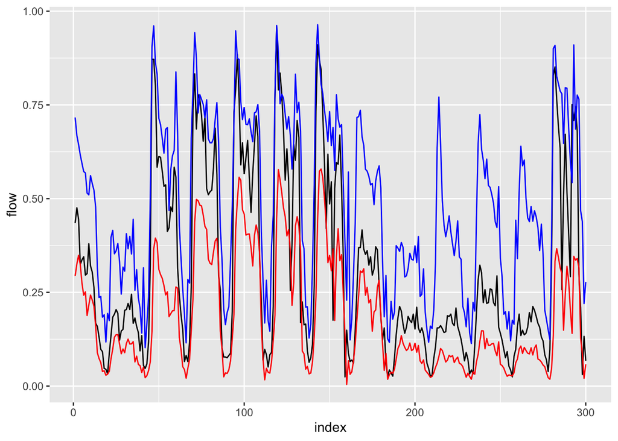

```r
ggplot(te1all[1:300,]) +
    geom_line(mapping = aes(x = index, y = flow), color = "black") +
    geom_line(mapping = aes(x = index, y = upper), color = "blue") +
    geom_line(mapping = aes(x = index, y = lower), color = "red")
```

> We see that model1 covers the flow inside the interval, nicely. However, it sometimes has very big intervals.

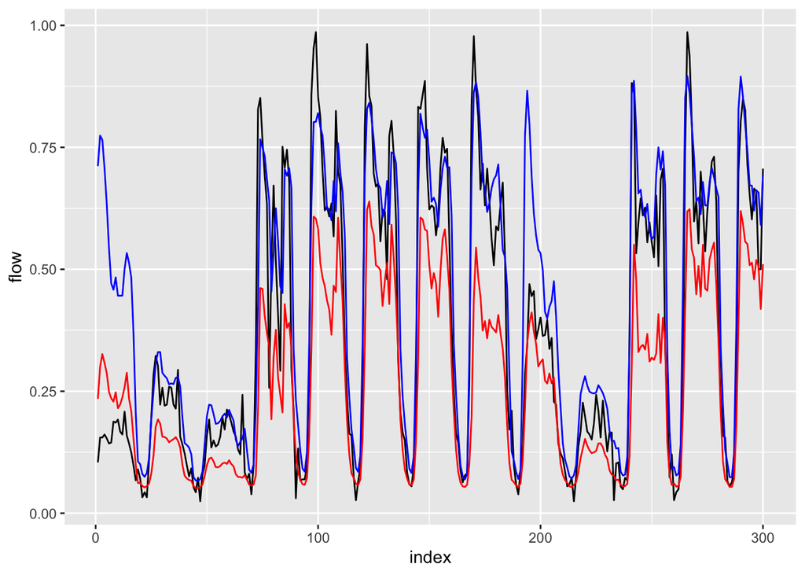

```r
ggplot(te3all[1:300,]) +
    geom_line(mapping = aes(x = index, y = flow), color = "black") +
    geom_line(mapping = aes(x = index, y = upper), color = "blue") +
    geom_line(mapping = aes(x = index, y = lower), color = "red")
```

### Measuring Performance

Winkler Score and Unconditional Coverage

| Data | Winkler Train | Winkler Test | Unconditional Coverage Train | Unconditional Coverage Test |
| --- | --- | --- | --- | --- |
| Data1 | 0.3182632 | 0.3231521 | 0.9218062 | 0.9144954 |
| Data2 | 0.2177761 | 0.2219309 | 0.7706763 | 0.7710508 |
| Data3 | 0.1957726 | 0.1909628 | 0.6790396 | 0.7146834 |
| Data4 | 0.1928564 | 0.1887284 | 0.6926111 | 0.7174669 |

> Smaller winkler score is better

> UC should be as close to 0.90 as possible. However we have some weird results here.

## Forecast Similarity

As forecasts, we will be using LSTM. Skipping most of that part.

**Results of LSTM:**

We are not interested in LSTM’s performance but just to compare with the previous project and check whether the model has a flaw.

Weird Catch: model$loss is different than hand-calculated loss

LSTM Results

| Data | Model Loss | Train | Test |
| --- | --- | --- | --- |
| Data1 | 28.64406 | 28.74575 | 32.26083 |
| Data2 | 26.01578 | 27.94562 | 28.47678 |
| Data3 | 26.03706 | 29.0444 | 27.78695 |
| Data4 | 26.14599 | 26.28531 | 24.08118 |

### Finding Closest Neighbors:

1. Euclidean Distance / Closest 20 Neighbors

Another Not useful table. Using LSTM forecasts to fix LSTM results sometimes work (point forecast)

| Data | Mae |
| --- | --- |
| Data1 | 31.59523 |
| Data2 | 28.57183 |
| Data3 | 28.59466 |
| Data4 | 28.85006 |

The Main Table. Comparison of winkler and UC scores.

[output not shown]